# Analisis Final

Benjamin Lira

2022-11-01

A continuación se presentan los resultados del análisis final

```r
library(tidyverse)
library(lavaan)
library(Ben)
library(gt)
# Custom functions
source("F.R")
theme_set(egg::theme_article())

# Custom functions
fa_tibble = function(fa,sort=T){
  if(!sort){l = fa$loadings}
  if(sort){l = psych::fa.sort(fa)$loadings}

  loadings = data.frame(matrix(as.numeric(l), attributes(l)$dim, dimnames=attributes(l)$dimnames)) |>
    rownames_to_column() |>
    as_tibble() |>
    rename(Item = rowname)
  return(loadings)
}


d <- read_csv("datosshiny.csv")
items <- read_csv("items.csv")
```

## Resultados

### Analisis factorial exploratorio

Un análisis factorial de un factor, extraido con el metodo de cuadrados no ponderados resulta en un modelo que captura el 52% de la varianza presente en los ítems.

```r
d |>
    select(B1_1,
B1_2,
B1_9,
B1_15,
B1_17,
B1_21,
B1_23,
B1_24,
B1_29,
B1_32) |>
    psych::fa(
      nfactors = 1,
     rotate = "varimax",
      fm = 'uls',
      cor = 'poly'
    )  |>
       fa_tibble(sort = T) |> left_join(items |> rename(Item = var)) |> select(item, starts_with("ULS")) %>%
  # mutate_at(2:ncol(.), ~Ben::numformat(., n=3)) |>
  gt::gt() |>
  fmt_number(
    columns = paste0("ULS",1)
  ) |>
   data_color(
    columns = paste0("ULS",1),
    colors = scales::col_numeric(
      palette = c("dark red", "white", "dark green"),
      domain = c(-1, 1)
    )
  )
```

| item | ULS1 |
| --- | --- |
| Me siento capaz de manejar las responsabilidades relacionadas con mis actividades académicas y/o laborales. | 0.85 |
| Me siento capaz de sentir confianza en mí mismo y demostrarlo. | 0.76 |
| Me siento capaz de organizar mis actividades académicas y/o laborales para terminarlo a tiempo. | 0.74 |
| Me siento capaz de mantener la objetividad en mis actividades académicas y/o laborales. | 0.73 |
| Me siento capaz de asumir distintas tareas en mis actividades académicas y/o laborales. | 0.72 |
| Me siento capaz de ser autónomo en mis actividades académicas y/o laborales. | 0.72 |
| Me siento capaz de manejar el estrés en mis actividades académicas y/o laborales. | 0.70 |
| Me siento capaz de tener buenas relaciones con las personas. | 0.67 |
| Me siento capaz de comunicarme sin problemas con mis compañeros. | 0.67 |
| Me siento capaz de defender mis ideas cuando la situación lo demanda. | 0.62 |

### Análisis factorial confirmatorio

```r
library(lavaan)
model <- "
capacidad =  ~ B1_1 + B1_2 + B1_9 + B1_15 + B1_17 + B1_21 + B1_23 + B1_24 +
B1_29 + B1_32
"
```

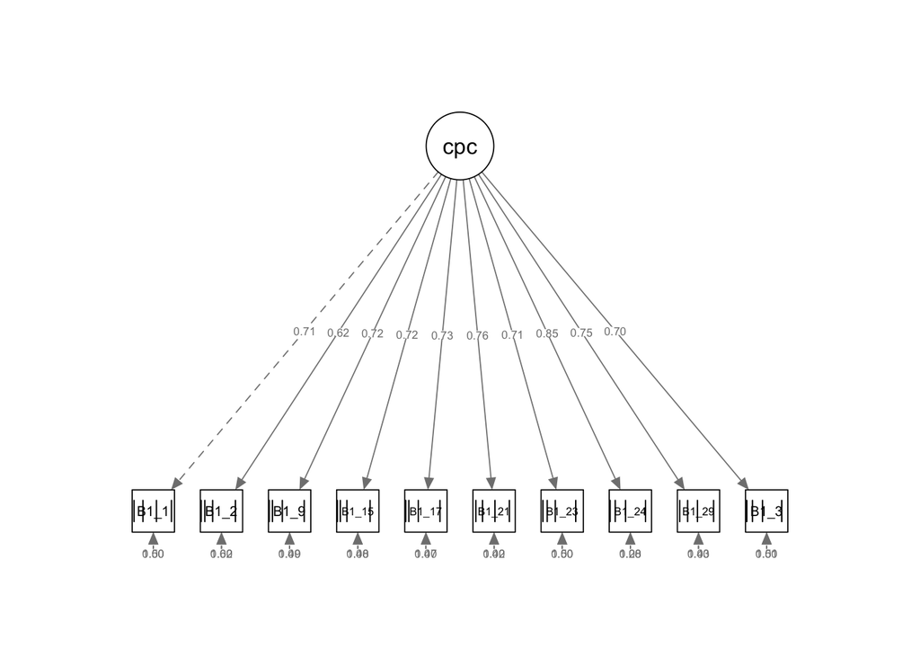

```r
fit <- cfa(model,data = d, ordered = T)
#summary(fit, rsquare = T, fit.measures = T, standardized = T)
semPlot::semPaths(fit,whatLabels = 'std', style = 'lisrel', intercepts= F)
```

El modelo tiene un fit bastante adecuado. $\chi^2$ = 362.84 [df = 35,N = 516], p <.001***, CFI = .99, TLI = .98, RMSEA = .10 [95% CI = .09 - .12], SRMR = .06

```r
min = fit |> broom::tidy() |> filter(op == "=~") |> pull(std.all) |> min() |> numformat()
max = fit |> broom::tidy() |> filter(op == "=~") |> pull(std.all) |> max() |> numformat()
```

Aquí podemos ver las cargas factoriales. Todas son significativas (p < .001), y de tamaños relativamente considerables (rango = .62 - .85.

```r
fit |>
  broom::tidy() |>
  filter(op == "=~") |>
  select(term, std.all, p.value) |>
  separate(term, c("Factor", "Item"), "=~") |>
  group_by(Factor) |>
  gt::gt() |>
  fmt_number(3) |>
   data_color(
    columns = 3,
    colors = scales::col_numeric(
      palette = c("dark red", "white", "dark green"),
      domain = c(-1, 1)
    )
  )
```

| Item | std.all | p.value |
| --- | --- | --- |
| capacidad |  |  |
| B1_1 | 0.71 | NA |
| B1_2 | 0.62 | 0 |
| B1_9 | 0.72 | 0 |
| B1_15 | 0.72 | 0 |
| B1_17 | 0.73 | 0 |
| B1_21 | 0.76 | 0 |
| B1_23 | 0.71 | 0 |
| B1_24 | 0.85 | 0 |
| B1_29 | 0.75 | 0 |
| B1_32 | 0.70 | 0 |

### Análisis de validez concurrente a nivel de ítems

A continuación se presenta las evidencias de validez convergente entre cada item y las variables criterio del estudio.

```r
d |>
    select(B1_1,
B1_2,
B1_9,
B1_15,
B1_17,
B1_21,
B1_23,
B1_24,
B1_29,
B1_32,
positive, negative, flour, familia) |>
  corrr::correlate() |>
  corrr::stretch() |>
  filter(str_detect(x, "B1_")) |>
  filter(!str_detect(y, "B1_")) |>
  pivot_wider(names_from = y, values_from = r) |>
  left_join(items |> select(x = var, item)) |>
  select(x, item, everything()) |>
  gt::gt() |>
  fmt_number(3:6,decimals = 3) |>
   data_color(
    columns = 3:6,
    colors = scales::col_numeric(
      palette = c("dark red", "white", "dark green"),
      domain = c(-1, 1)
    )
  )
```

```
##
## Correlation method: 'pearson'
## Missing treated using: 'pairwise.complete.obs'
```

| x | item | positive | negative | flour | familia |
| --- | --- | --- | --- | --- | --- |
| B1_1 | Me siento capaz de manejar el estrés en mis actividades académicas y/o laborales. | 0.423 | −0.485 | 0.363 | 0.082 |
| B1_2 | Me siento capaz de defender mis ideas cuando la situación lo demanda. | 0.386 | −0.357 | 0.425 | 0.109 |
| B1_9 | Me siento capaz de asumir distintas tareas en mis actividades académicas y/o laborales. | 0.406 | −0.309 | 0.328 | 0.045 |
| B1_15 | Me siento capaz de ser autónomo en mis actividades académicas y/o laborales. | 0.310 | −0.315 | 0.341 | 0.074 |
| B1_17 | Me siento capaz de mantener la objetividad en mis actividades académicas y/o laborales. | 0.332 | −0.400 | 0.311 | 0.090 |
| B1_21 | Me siento capaz de sentir confianza en mí mismo y demostrarlo. | 0.544 | −0.462 | 0.476 | 0.129 |
| B1_23 | Me siento capaz de tener buenas relaciones con las personas. | 0.398 | −0.391 | 0.471 | 0.143 |
| B1_24 | Me siento capaz de manejar las responsabilidades relacionadas con mis actividades académicas y/o laborales. | 0.450 | −0.472 | 0.376 | 0.122 |
| B1_29 | Me siento capaz de organizar mis actividades académicas y/o laborales para terminarlo a tiempo. | 0.429 | −0.429 | 0.334 | 0.134 |
| B1_32 | Me siento capaz de comunicarme sin problemas con mis compañeros. | 0.384 | −0.417 | 0.420 | 0.190 |

### Confiabilidad

```r
alfa= d |>
    select(B1_1,
B1_2,
B1_9,
B1_15,
B1_17,
B1_21,
B1_23,
B1_24,
B1_29,
B1_32) |>
  psych::alpha()
```

La escala de 10 items cuenta con niveles adecuados de confiabilidad. El alfa es de .88, con correlaciones item-total en el rango de .55 - .73.

### Relaciones con otras variables

La siguiente matriz de correlaciones muestra las correlaciones entre el sentido de capacidad, afecto positivo y negativo, florecimiento, y la escala de funcionmiento familiar. Se aprecian correlaciones significativas y practicamente relevantes con afecto positivo y florecimiento, demostrando evidencias de validez concurrente.

```r
d |>
  mutate(capacidad = alfa$scores) |>
  select(capacidad, positive, negative, flour, familia) |>
  Ben::harcor() |>
  gt()
```

|  | 1 | 2 | 3 | 4 | 5 |
| --- | --- | --- | --- | --- | --- |
| 1. capacidad |  |  |  |  |  |
| 2. positive | .58*** |  |  |  |  |
| 3. negative | -.58*** | -.26*** |  |  |  |
| 4. flour | .55*** | .39*** | -.43*** |  |  |
| 5. familia | .16*** | .10* | -.12** | .18*** |  |
| M | 4.19 | 2.85 | 2.42 | 3.44 | 3.53 |
| SD | 0.98 | 0.73 | 0.80 | 0.79 | 0.84 |
| n | 516 | 516 | 516 | 516 | 516 |